# Tutorial on ADVANCED ALAAM - NCRM

[Johan Koskinen](https://https://www.su.se/english/profiles/kosk-1.615440)

2024-11-01

# Introduction

This tutorial introduces *more advanced* aspects of the Bayesian estimation for auto-logistic actor attribute models (ALAAMs)(Robins, Pattison, and Elliott (2001), Daraganova (2009), and Daraganova and Robins (2013)) developed in Koskinen and Daraganova (2022).

The workshop will go through

1. Data missing at random
2. Data missing not at random
3. More contagion effects
4. Interacting contagion with other effects
5. Specifying “informative” prior distributions

## Preamble for ALAAM

Load the main functions of `balaam’ from GitHub and load network packages.

```r
source("https://raw.githubusercontent.com/johankoskinen/ALAAM/main/balaam.R")
require(sna)
require(network)
```

and don’t forget to consult the (proto-) manual is avaialble on GitHub [alaam_effects](https://github.com/johankoskinen/ALAAM/blob/main/alaam_effects.pdf).

## Load and format data

WThe s50 dataset

```r
temp <- tempfile()
download.file("https://www.stats.ox.ac.uk/~snijders/siena/s50_data.zip",temp)
adj <- as.matrix( read.table(unz(temp, "s50-network1.dat")) )
sport <- read.table(unz(temp, "s50-sport.dat"))
smoke <- read.table(unz(temp, "s50-smoke.dat"))
alcohol <- read.table(unz(temp, "s50-alcohol.dat"))
unlink(temp)
```

format

```r
n <- nrow(adj)
adj <- as.matrix(adj) # convert from data.frame to matrix
smoke <- smoke[,2] # use wave 2
smoke[smoke<2] <- 0 # set non-smoker to 0
smoke[smoke>0] <- 1 # set occasional and regular to 1
sport <- sport-1
my.data <- data.frame(smoke=smoke, alcohol=alcohol[,1],sport=sport[,1])
```

# MAR data

The ALAAM routine automatically handles missing data in the dependent variable. Set smoking to missing for a the first five individuals

```r
true.vals <- my.data$smoke[1:5]
my.data$smoke[1:5] <- NA
table(my.data$smoke, useNA='always')
```

```
##
##    0    1 <NA>
##   29   16    5
```

Assuming that data are missing at random (MAR),

```r
res.MAR.0 <- estimate.alaam(smoke ~odegree+alcohol+sport+simple,
                            my.data, adjacency=adj,
                           Iterations=1000,
                           missFreq = 500)
```

```
## Network is directed with  50 nodes
```

```
## [1] "you have  5  missing entries in response"
## NULL
## [1] "you have p:  5"
##
## observed stats:  16 21 41 57 11
## number of covariates:  3
## A thinning of  1 ,
## (parameter) burn-in of  1 , and
## iterations of  1000 ,
## yields a sample size of  1000 .
##
## you have done  100  iterations out of  1000
## theta: -4.587 0.445 0.139 1.012 -0.189
## observed stats:  18 24 44 63 13
##
## imputed ones:  2  out of  5
##
## you have done  200  iterations out of  1000
## theta: -2.185 0.143 0.111 0.805 -1.592
## observed stats:  18 24 44 63 13
##
## imputed ones:  2  out of  5
##
## you have done  300  iterations out of  1000
## theta: -3.476 0.427 -0.047 0.639 0.415
## observed stats:  19 25 46 64 13
##
## imputed ones:  3  out of  5
##
## you have done  400  iterations out of  1000
## theta: -3.704 0.068 0.572 0.798 -1.745
## observed stats:  17 24 43 60 12
##
## imputed ones:  1  out of  5
##
## you have done  500  iterations out of  1000
## theta: -4.536 -0.179 0.836 0.624 0.54
## observed stats:  18 24 44 63 13
##
## imputed ones:  2  out of  5
```

[output cut: 30 more lines]

```
##
## summaries of the posterior draws:
##              mean      sd     ESS SACF 10 SACF 30
## intercept -3.2712  1.2931 30.0442  0.5724  0.1471
## contagion  0.2244  0.2777 30.2033  0.4989  0.0918
## odegree    0.0752  0.3022 31.3927  0.5028  0.3184
## alcohol    0.8192  0.4250 20.6673  0.6557  0.1939
## sport     -0.7304  0.7254 30.4178  0.5634  0.2948
##
## if ESS is small you need to increase the number of Iterations
## if and/or increase the parameter thinning which is currently  1 .
## Alternatively, adjust the proposals by improving the proposal variance-covariance:
## e.g. set PropSigma equal to the covariance of the posterior draws, or
## increase/decrease the scaling of the proposals (default: scaling=1/sqrt( 5 ); current:  1 /sqrt( 5 )
## Acceptance ratio:  0.286  (idealy around 0.25)
```

The output to screen that says for example imputed ones: 2 out of 5, tells us how many of the 5 missing values in that iteration that have been imputed with a 1.

> With 10% or responses missing we see some attenuation of effects (standard deviations increase)

### Check imputations

The imputed values are stored in `res.MAR.0$imputed.obs`, and here we can compare the imputed values with the true values

```r
table(rowMeans(res.MAR.0$imputed.obs[1:5,]),true.vals)
```

```
##        true.vals
##         0 1
##   0.108 1 0
##   0.198 1 0
##   0.22  1 0
##   0.322 0 1
##   0.346 1 0
```

## GOF with missing

In the ordinary GOF the observed statistics are compared with the simulated statistics. When we have missing data, we do not have one value for each statistic, but a range of values.

```r
sim.2.na <- get.gof.distribution(NumIterations=500, # number of vectors to draw
                                  res=res.MAR.0, # the ALAAM estimation object that contains model and results
                                  burnin=100, # no. iterations discarded from GOF distribution
                                  thinning = 1000, # no. iterations between sample points
                                  contagion ='simple') #
```

```
## Simulating GOF took  4.60739
## Calculating statistics took  0.297092
```

When calculating the statistics, we need to add the argument `Imp.gof`

```r
gof.table(obs.stats=    sim.2.na$stats, # observed statistics included  not fitted statistics
          sim.stats=    sim.2.na$Sav.gof, # simulated goodness-of-fit statistics
          name.vec= sim.2.na$gof.stats.names, # names of statistics calculate, not all will be used if undirected
          tabname='ALAAMGofalt', # name of file saved
          pvalues=TRUE, # posterior predictive p-values
          save.tab ='csv', # save a csv file or a LaTex file
          Imp.gof = sim.2.na$Imp.gof)
```

```
##                      obs    mean   p-val
## intercept         17.194  17.834   0.206
## simple cont.      23.386  25.748   0.234
## recip cont.        6.020   8.920   0.122
## indirect cont.    53.112  46.986   0.172
## closedind cont.   22.406  22.660   0.252
## transitive cont.  13.692  16.462   0.218
## outdegree         43.190  43.474   0.252
## indegree          39.844  47.910   0.140
## reciprochation    25.844  30.678   0.127
## instar            56.650  69.580   0.118
## outstar           43.996  41.454   0.190
## twopath           87.646 100.860   0.184
## in3star           71.000  76.786   0.109
## out3star          22.000  19.348   0.175
## transitive        35.002  34.254   0.209
## cyclic            18.656  25.736   0.098
## indirect          93.268  83.388   0.175
## excl.indirect     52.266  44.812   0.151
```

### Plot goodness of fit with missing

We can compare the statistics for the predictive distribution under the fitted model, with the imputed or complemented datasets. Look at the statistic for ‘indirect contagion’

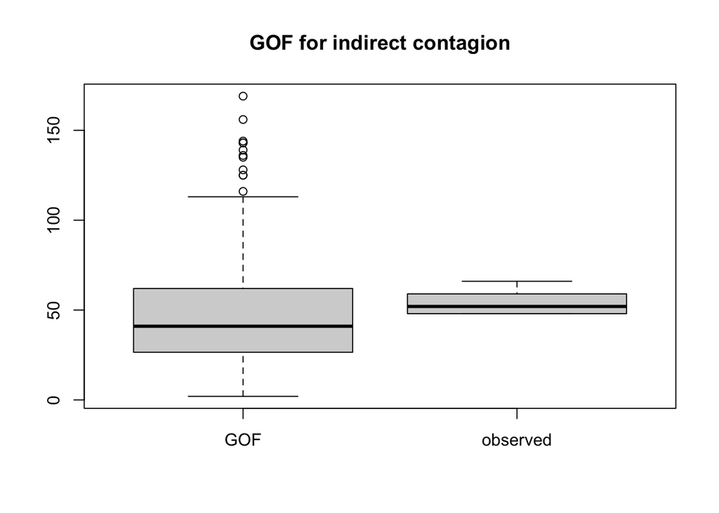

```r
boxplot(sim.2.na$Sav.gof[4,],sim.2.na$Imp.gof[4,],names = c('GOF','observed'), main='GOF for indirect contagion')
```

### Posterior deviance

With missing data, the likelihood is marginalised with respect to the missing entries when calculating the posterior deviance.

```r
# Bug prevents this from runnig
my.dev.post.MAR <- post.deviance.alaam(res.MAR.0,# the estimation object
                                  numBridges=5,# the safer default is 20
                                  thinning.like = 1000,# thinning in drawing y; should be higher
                                  sample.size = 20,# number of y drawn for each bridge
                                  cov.sample.burnin = NULL,
                                  printFreq=10,# print to screen after done 10
                                  mult.fact = 30,# depreciated
                                  num.outs=100)# number of devaiance evaluations to return
```

# MNAR data

```r
res.MNAR.0 <- estimate.alaam(smoke ~idegree+odegree+alcohol+sport+simple,
                            my.data, adjacency=adj,
                           Iterations=1000,
                           missFreq = 500,
                           missingPhi =0.5)
```

```
## Network is directed with  50 nodes
## [1] "you have  5  missing entries in response"
## NULL
## [1] "you have p:  6"
##
## observed stats:  16 21 38 41 57 11
## number of covariates:  4[1] "MNAR mechanism specified based on response and    covariates"
##
## A thinning of  1 ,
## (parameter) burn-in of  1 , and
## iterations of  1000 ,
## yields a sample size of  1000 .
##
## you have done  100  iterations out of  1000
## theta: -3.763 0.624 -0.456 0.344 0.577 0.964
## observed stats:  18 25 41 44 62 12
##
## imputed ones:  2  out of  5
##
## you have done  200  iterations out of  1000
## theta: -2.77 0.704 -1.255 0.708 1.247 -1.622
## observed stats:  18 28 41 45 62 12
##
## imputed ones:  2  out of  5
##
## you have done  300  iterations out of  1000
## theta: -0.372 0.478 -0.844 0.008 0.806 -2.55
## observed stats:  18 25 42 45 61 12
##
## imputed ones:  2  out of  5
##
## you have done  400  iterations out of  1000
## theta: -6.857 0.365 -1.916 1.477 2.111 -0.659
## observed stats:  17 24 39 43 60 12
##
## imputed ones:  1  out of  5
##
## you have done  500  iterations out of  1000
## theta: -3.376 0.559 -0.954 0.389 1.098 -0.528
## observed stats:  18 28 41 45 62 12
```

[output cut: 33 more lines]

```
## summaries of the posterior draws:
##              mean      sd     ESS SACF 10 SACF 30
## intercept -3.8627  1.9066 18.1484  0.6555  0.1435
## contagion  0.6602  0.2582 34.1698  0.5167  0.0323
## idegree   -0.8256  0.3807 16.7686  0.7396  0.3648
## odegree    0.3385  0.3865 25.7448  0.5517  0.0986
## alcohol    1.1271  0.4653 21.2711  0.6455  0.1883
## sport     -0.6049  1.0206 11.6928  0.7969  0.5166
##
## if ESS is small you need to increase the number of Iterations
## if and/or increase the parameter thinning which is currently  1 .
## Alternatively, adjust the proposals by improving the proposal variance-covariance:
## e.g. set PropSigma equal to the covariance of the posterior draws, or
## increase/decrease the scaling of the proposals (default: scaling=1/sqrt( 6 ); current:  1 /sqrt( 6 )
## Acceptance ratio:  0.306  (idealy around 0.25)
```

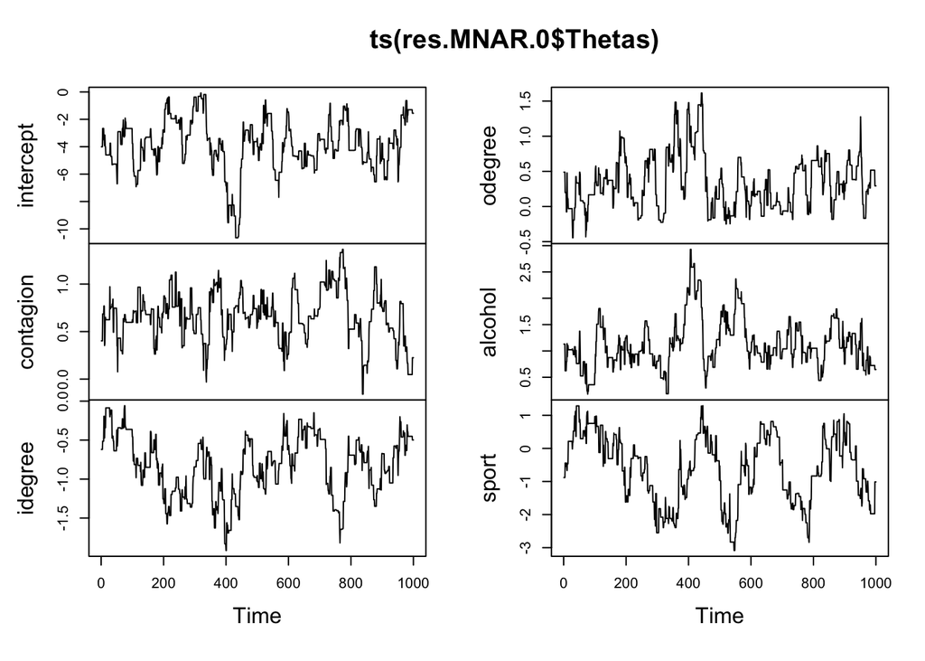

```r
plot(ts(res.MNAR.0$Thetas))
```

### Sensitivity analysis

If perform the analysis for a range of different values of $\gamma$, you would compare the posteriors under different MNAR assumptions. Of particular interest is to ascertain how strong the bias has to be for your conclusions to be qualitatively different compare to MAR.

# More contagion

## Reciprocal contagion

Reinstate the missing values

```r
my.data$smoke[1:5] <- true.vals
table(my.data$smoke, useNA='always')
```

```
##
##    0    1 <NA>
##   33   17    0
```

Given that we have directed network data, we may want to investigate if there is stronger or weaker contagion across reciprocated ties.

> For non-direct congation effects, the lower order contagion as well as any other lower-oder statistics need to be included.

Consequently we define the model

```r
res.DC.RC.1 <- estimate.alaam(smoke ~ odegree+alcohol+sport+simple+recipties+recip,
                              my.data, adjacency=adj,
                           Iterations=5100,
                        par.burnin=100,# discard the first 100 iterations
                        thinning=10)# only use every
```

```
## Network is directed with  50 nodes
## [1] "you have p:  7"
##
## observed stats:  17 25 7 43 59 11 26
## number of covariates:  4
## A thinning of  10 ,
## (parameter) burn-in of  100 , and
## iterations of  5100 ,
## yields a sample size of  501 .
##
## you have done  510  iterations out of  5100
## theta: -4.306 0.832 -0.577 0.523 1.671 -1.629 -1.837
## you have done  1020  iterations out of  5100
## theta: -2.913 0.081 0.116 -0.081 1.069 0.273 -0.169
## you have done  1530  iterations out of  5100
## theta: -2.51 0.778 -2.015 0.4 1.005 -1.371 -1.141
## you have done  2040  iterations out of  5100
## theta: -1.807 0.435 -0.671 0.128 0.945 -1.503 -0.881
## you have done  2550  iterations out of  5100
## theta: -3.977 0.06 0.963 0.712 1.263 -1.116 -1.54
## you have done  3060  iterations out of  5100
## theta: -3 1.485 -1.72 -0.082 0.91 0.623 -1.686
## you have done  3570  iterations out of  5100
## theta: -5.763 -0.552 1.999 1.214 1.263 -0.369 -1.287
## you have done  4080  iterations out of  5100
## theta: -4.289 0.638 0.179 0.965 1.222 -1.317 -1.574
## you have done  4590  iterations out of  5100
## theta: -1.767 0.737 0.005 0.101 1.054 -1.162 -1.89
## you have done  5100  iterations out of  5100
## theta: -1.922 1.287 -2.468 -0.254 0.253 -1.202 0.509
## summaries of the posterior draws:
##                mean       sd      ESS  SACF 10 SACF 30
## intercept   -3.0572   1.5410  90.8629  -0.0399
## contagion    0.7083   0.4976 114.7889   0.0193
## recip cont  -0.6869   1.1793 115.9395  -0.0186
## odegree      0.3329   0.4629 110.2057  -0.0728
## alcohol      0.9556   0.4180  97.8905  -0.0984
## sport       -0.7675   0.8687 117.9612  -0.0031
## recipties   -1.1177   0.7006  82.7490   0.0029
##
## if ESS is small you need to increase the number of Iterations
## if and/or increase the parameter thinning which is currently  10 .
## Alternatively, adjust the proposals by improving the proposal variance-covariance:
## e.g. set PropSigma equal to the covariance of the posterior draws, or
## increase/decrease the scaling of the proposals (default: scaling=1/sqrt( 7 ); current:  1 /sqrt( 7 )
## Acceptance ratio:  0.2692157  (idealy around 0.25)
```

> How are parameters for contagion, reciprochal contagion and reciprocal ties related?

# Interacting contagion

Assume that we hypothesis that social influence on smoking is stronger for heavy drinkers than others. We can test this hypothesis by interacting contagion with alcohol

```r
res.DC.ADC.1 <- estimate.alaam(smoke ~ odegree+alcohol+sport+simple+alcohol*simple,
                              my.data, adjacency=adj,
                           Iterations=5100,
                        par.burnin=100,# discard the first 100 iterations
                        thinning=10)# only use every
```

```
## Network is directed with  50 nodes
## [1] "you have p:  6"
##
## observed stats:  17 25 43 59 11 99
## number of covariates:  3
## A thinning of  10 ,
## (parameter) burn-in of  100 , and
## iterations of  5100 ,
## yields a sample size of  501 .
##
## you have done  510  iterations out of  5100
## theta: -2.771 0.247 0.168 0.87 -1.153 -0.039
## you have done  1020  iterations out of  5100
## theta: -2.567 0.096 -0.032 0.77 -0.732 0.018
## you have done  1530  iterations out of  5100
## theta: -2.764 0.152 0.081 0.517 0.118 0.075
## you have done  2040  iterations out of  5100
## theta: -3.099 0.316 -0.004 1.199 -1.15 -0.075
## you have done  2550  iterations out of  5100
## theta: -3.372 0.182 0.129 0.601 -0.343 0.05
## you have done  3060  iterations out of  5100
## theta: -2.541 0.464 -0.062 0.581 -1.531 0.056
## you have done  3570  iterations out of  5100
## theta: -4.325 0.685 -0.298 0.962 -0.09 -0.038
## you have done  4080  iterations out of  5100
## theta: -2.772 0.447 0.298 0.007 -0.25 0.084
## you have done  4590  iterations out of  5100
## theta: -3.569 0.106 0.275 0.468 -0.162 0.129
## you have done  5100  iterations out of  5100
## theta: -3.773 0.76 0.15 1.072 -1.199 -0.112
## summaries of the posterior draws:
##                               mean       sd      ESS  SACF 10 SACF 30
## intercept                  -3.1669   1.3127 134.2762   0.0923
## contagion                   0.3089   0.3162  83.4834   0.0197
## odegree                     0.0106   0.3501 160.2456  -0.0661
## alcohol                     0.8188   0.3710 145.5803   0.0708
## sport                      -0.9293   0.7682 125.0047   0.0123
## interaction  2 :  alcohol   0.0075   0.0564  19.6265   0.4461
##
## if ESS is small you need to increase the number of Iterations
## if and/or increase the parameter thinning which is currently  10 .
## Alternatively, adjust the proposals by improving the proposal variance-covariance:
## e.g. set PropSigma equal to the covariance of the posterior draws, or
## increase/decrease the scaling of the proposals (default: scaling=1/sqrt( 6 ); current:  1 /sqrt( 6 )
## Acceptance ratio:  0.33  (idealy around 0.25)
```

# Informative priors

The inference pressuposes a prior (subjective) prior distribution $\pi(\textbf{\theta})$ for parameters. The default in `estimate.alaam` is to set this prior constant (and therefore improper). There are cases where you need a proper prior distribution. For example, if you want to calculate so-called Bayes-factors. For some data and model combinations, nuisance parameters might need to be included but not desired to be estimated.

There are two types of standard prior distributions.

## Shrinkage prior

A convenient prior is
$$\boldsymbol{\theta} \thicksim \mathcal{N}_p(\boldsymbol{\mu},\lambda
I^{-1})$$
where $\boldsymbol{\mu}$ is all zero, except $\mu_1$ which is set to the MLE for the intercept. For variance, $\lambda>0$ is a chosen shrinkage and $I$ is an approximation to the information matrix.

The argument to `estimate.alaam` is `scalePrior`. Calling this $c$, the prior variance-covariance is set to
$$c\left\{\mathbb{E}_{\boldsymbol{\mu}}[\boldsymbol{z}(\boldsymbol{y})\boldsymbol{z}(\boldsymbol{y})^{\top}]-\mathbb{E}_{\boldsymbol{\mu}}[\boldsymbol{z}(\boldsymbol{y})]\mathbb{E}_{\boldsymbol{\mu}}[\boldsymbol{z}(\boldsymbol{y})]^{\top}\right\}^{-1}$$
## Subjective prior

A suybjectively determined normal prior
$$\boldsymbol{\theta} \thicksim
\mathcal{N}_p(\boldsymbol{\mu},\boldsymbol{\Sigma})$$
can be specified by passing the arguments `priorMu` and `priorSigma` to `estimate.alaam`.

### Example

In the last model, we have

```r
dim(res.DC.ADC.1$Thetas)[2]
```

```
## [1] 6
```

```r
priorSigma <- diag(c(1,.2,.1,1,.0001,.01))
priorMu <- matrix(0,6,1)
```

Reestimate with additional arguments `priorSigma` and `priorMu`

```r
res.DC.ADC.prior.0 <- estimate.alaam(smoke ~ odegree+alcohol+sport+simple+alcohol*simple,
                              my.data, adjacency=adj,
                           Iterations=1000,
                        par.burnin=100,# discard the first 100 iterations
                        thinning=3,# only use every
                        prevBayes = res.DC.ADC.1,
                        priorSigma = priorSigma,
                        priorMu =priorMu)
```

```
## [1] "you have p:  6"
##
## observed stats:  17 25 43 59 11 99
## number of covariates:  3
## A thinning of  3 ,
## (parameter) burn-in of  100 , and
## iterations of  1000 ,
## yields a sample size of  301 .
##
## you have done  100  iterations out of  1000
## theta: -5.038 0.995 -0.158 0.917 -0.341 -0.044
## you have done  200  iterations out of  1000
## theta: -5.889 0.423 0.378 1.289 0.024 -0.072
## you have done  300  iterations out of  1000
## theta: -2.459 0.82 -0.047 0.451 -1.537 -0.009
## you have done  400  iterations out of  1000
## theta: -4.578 0.631 0.351 0.772 -0.682 -0.078
## you have done  500  iterations out of  1000
## theta: -3.463 0.866 0.103 0.66 -0.824 -0.09
## you have done  600  iterations out of  1000
## theta: -2.733 0.174 -0.174 1.159 -0.258 -0.062
## you have done  700  iterations out of  1000
## theta: -5.078 0.212 0.262 1.309 -0.526 -0.031
## you have done  800  iterations out of  1000
## theta: -4.143 0.172 0.383 0.776 -0.944 -0.001
## you have done  900  iterations out of  1000
## theta: -7.35 0.853 0.68 1.399 -1.188 -0.052
## you have done  1000  iterations out of  1000
## theta: -2.498 0.182 -0.01 0.475 -0.302 0.05
## summaries of the posterior draws:
##                              mean      sd     ESS SACF 10 SACF 30
## intercept                 -3.9371  1.3334 15.4019  0.0762
## contagion                  0.4854  0.3423 10.0869  0.3035
## odegree                    0.1550  0.3507 13.8616  0.4197
## alcohol                    0.8590  0.3278 22.6688  0.0942
## sport                     -0.7088  0.7690 17.0076  0.1428
## interaction  2 :  alcohol -0.0432  0.0413  5.6796  0.6363
##
## if ESS is small you need to increase the number of Iterations
## if and/or increase the parameter thinning which is currently  3 .
## Alternatively, adjust the proposals by improving the proposal variance-covariance:
## e.g. set PropSigma equal to the covariance of the posterior draws, or
## increase/decrease the scaling of the proposals (default: scaling=1/sqrt( 6 ); current:  1 /sqrt( 6 )
## Acceptance ratio:  0.521  (idealy around 0.25)
```

```r
res.DC.ADC.prior.1 <- estimate.alaam(smoke ~ odegree+alcohol+sport+simple+alcohol*simple,
                              my.data, adjacency=adj,
                           Iterations=5100,
                        par.burnin=100,# discard the first 100 iterations
                        thinning=10,# only use every
                        prevBayes = res.DC.ADC.prior.0,
                        priorSigma = priorSigma,
                        priorMu =priorMu)
```

```
## [1] "you have p:  6"
##
## observed stats:  17 25 43 59 11 99
## number of covariates:  3
## A thinning of  10 ,
## (parameter) burn-in of  100 , and
## iterations of  5100 ,
## yields a sample size of  501 .
##
## you have done  510  iterations out of  5100
## theta: -7.221 0.34 0.948 1.163 -1.002 0.019
## you have done  1020  iterations out of  5100
## theta: -3.888 0.669 -0.015 0.961 -1.131 -0.044
## you have done  1530  iterations out of  5100
## theta: -2.093 0.734 -0.26 0.69 -1.602 -0.012
## you have done  2040  iterations out of  5100
## theta: -5.397 0.037 0.31 1.439 -2.053 0.021
## you have done  2550  iterations out of  5100
## theta: -1.795 0.036 -0.242 0.809 -1.965 0.065
## you have done  3060  iterations out of  5100
## theta: -2.392 0.373 -0.22 0.57 -1.814 0.126
## you have done  3570  iterations out of  5100
## theta: -2.464 0.176 -0.389 0.878 -1.625 0.121
## you have done  4080  iterations out of  5100
## theta: -2.486 0.369 0.135 1.145 -3.625 -0.018
## you have done  4590  iterations out of  5100
## theta: -0.67 0.19 -0.037 0.215 -1.407 0.043
## you have done  5100  iterations out of  5100
## theta: -3.892 0.411 0.238 0.68 0 -0.044
## summaries of the posterior draws:
##                              mean      sd     ESS SACF 10 SACF 30
## intercept                 -2.8446  1.4512 42.8576  0.0968
## contagion                  0.2752  0.2935 53.2684  0.2364
## odegree                   -0.0400  0.3715 42.6558  0.1287
## alcohol                    0.7299  0.3865 49.3290  0.1040
## sport                     -1.1534  0.8696 36.4919  0.2312
## interaction  2 :  alcohol  0.0403  0.0574  7.9879  0.6667
##
## if ESS is small you need to increase the number of Iterations
## if and/or increase the parameter thinning which is currently  10 .
## Alternatively, adjust the proposals by improving the proposal variance-covariance:
## e.g. set PropSigma equal to the covariance of the posterior draws, or
## increase/decrease the scaling of the proposals (default: scaling=1/sqrt( 6 ); current:  1 /sqrt( 6 )
## Acceptance ratio:  0.6782353  (idealy around 0.25)
```

# Performing ALAAM where networks are imputed from ERGM

Assuming that there are missing tie-variables (and possibly other missing covariates), let’s assume that we have $G$ networks $x^{[1]},\ldots,x^{[2]}$ imputed from $ERGM(\beta)$, that has been marginalised with respect to $\beta$. Let us denote the predictive distribution of the $x^{[g]}$’s by $p(x)$, then the implied posterior for $\theta$ is based on the likelihood

$$E_x(p(y| x, \theta ))=\sum_{x}p(y| x, \theta ) p(x)$$

When calculating the deviance,
$$\ell (\theta ; y) = \log \{ E_x(p(y| x, \theta )) \}$$
We can use a Monte Carlo estimate for the expectation

$$\hat{\ell} (\theta ; y) = \log \frac{1}{G} \sum_g \exp{\ell (\theta ;
y,x^{[g] })}$$
This quantity is straightforward to calculate by calculating the relative likelihoods for each set of imputations. The likelihoods need to be calculated for the same parameter values however. When there are missing values in the outcome $y$, imputations on the outcome are needed for the calculations.

### A simplified pooling of posterior deviances

using `r'aitkinPostDev'` and adding the independent likelihood obtained from `independLike`.

> The point estimate for the independent model $\hat{\theta}$ needs to be the same across all $g=\ldots,G$

For the posterior deviance we can then base the ECDF on combining the individual deviances
$$-2\hat{\ell} (\theta^{[1,1]} ; y),\ldots,-2\hat{\ell} (\theta^{[K,1]} ;
y),\ldots,-2\hat{\ell} (\theta^{[1,G]} ; y),\ldots,-2\hat{\ell}
(\theta^{[K,G]} ; y)$$

# References

Daraganova, Galina. 2009. *Statistical Models for Social Networks and Network-Mediated Social Influence Processes: Theory and Applications*. University of Melbourne.

Daraganova, Galina, and Garry Robins. 2013. “Autologistic Actor Attribute Models.” In *Exponential Random Graph Models for Social Networks: Theory, Methods and Applications*, edited by Lusher D., Koskinen J., and G. Robins, 102–14. NY: Cambridge University Press New York.

Koskinen, Johan, and Galina Daraganova. 2022. “Bayesian Analysis of Social Influence.” *Journal of Royal Statistical Society, Series A* 185 (4): 1855–81.

Robins, Garry, Philippa Pattison, and Peter Elliott. 2001. “Network Models for Social Influence Processes.” *Psychometrika* 66 (2): 161–89.